# TS_FinalProject_Ferraro_Norelli_YU

Ricco, Nicole & Nick

2022-03-26

#### Data Read in & Wrangling

- This part is for reading in all related data frame, cleaning them extracting all data from 2000-1 - 2022-02 time period
- The resulting data frame is stored under ‘df’ variable
- You can run whole chunk directly after fixed file location

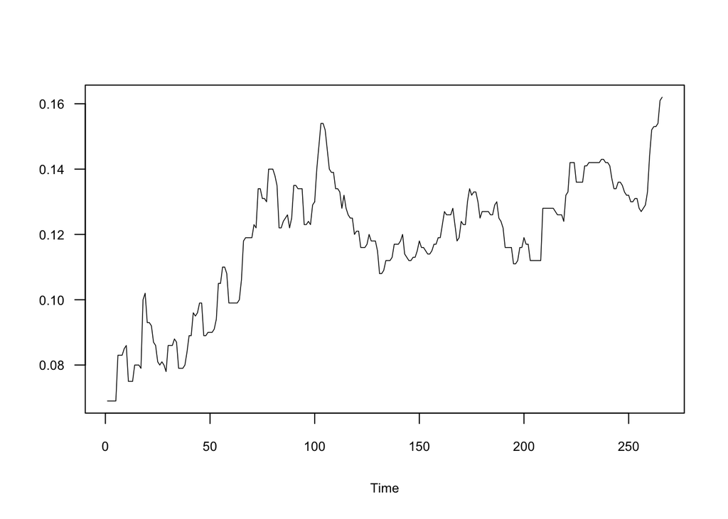

```r
library(tswge)
library(dplyr)
library(tidyverse)
library(readxl)
# Set this to data folder for your file
#setwd("/Users/riccoferraro/Documents/SMU/TimeSeries/TimeSeriesFinalProject/data")
setwd("/Users/mingyang/Desktop/SMU/TimeSeries/TimeSeriesFinalProject/data")
# Read in DFWA electricity Data
dfwa.electricity = read.csv("AVG_ELEC_DFWA_TX.csv",col.names = c("DATE", "AVG_EP"),
                          colClasses = c(DATE="character", AVG_EP="character"))

# Read in CPI data for Southern Urban area
cpi = read_excel("SouthernUrbanCPI.xlsx",sheet = "BLS Data Series", skip = 11)
# Getting rid of Half1 and Half2 which starts with S
cpi = cpi %>% filter(!grepl('S',Period) )
# Getting rid of Annual which labeled as M13
cpi = cpi %>% filter(!grepl('M13',Period) )

# Read in Gas Price data from same area
gas.price = read.csv("Dallas_FWA_GAS.csv")

# Read in Temperature Data & cleaning
temp = read_excel("DallasAreaTemp.xlsx", sheet = "Sheet1")
temp = temp %>% tidyr::pivot_longer(
  cols = starts_with("Mon_"),
  names_to = "Month",
  values_to = "Temperature"
)
temp = temp[1:386,]

# subset dataset
# which(dfwa.electricity$DATE=="1990-01-01") # 135
dfwa.electricity = dfwa.electricity[135:520,]
rownames(dfwa.electricity) <- 1:nrow(dfwa.electricity)

# which(cpi$Year==1990 & cpi$Period=="M01")
cpi = cpi[91:476,]
rownames(cpi) <- 1:nrow(cpi)

# which(gas.price$DATE=="1990-01-01") # 145
gas.price = gas.price[145:530,]
rownames(gas.price) <- 1:nrow(gas.price)


#### Creating ultimate data frame under variable 'df' ####
df = dfwa.electricity
df$CPI = cpi$Value
df$GAS_P = gas.price$APUS37A7471A
df$AVG_EP = as.numeric(df$AVG_EP)
df$TEMP = temp$Temperature

#### Due to distribution market deregulation in 1995, team decided to cut the realization
#### prior to 2000
# which(df$DATE=="2000-01-01") # 121
df = df[121:386,]
rownames(df) <- 1:nrow(df)

plotts.wge(df$AVG_EP)
```

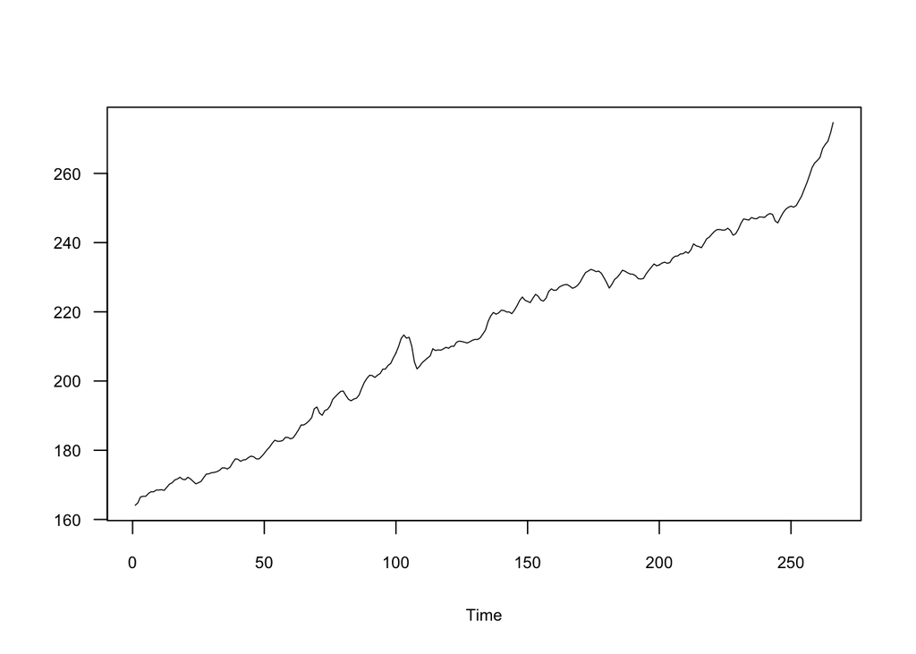

```r
plotts.wge(df$CPI)
```

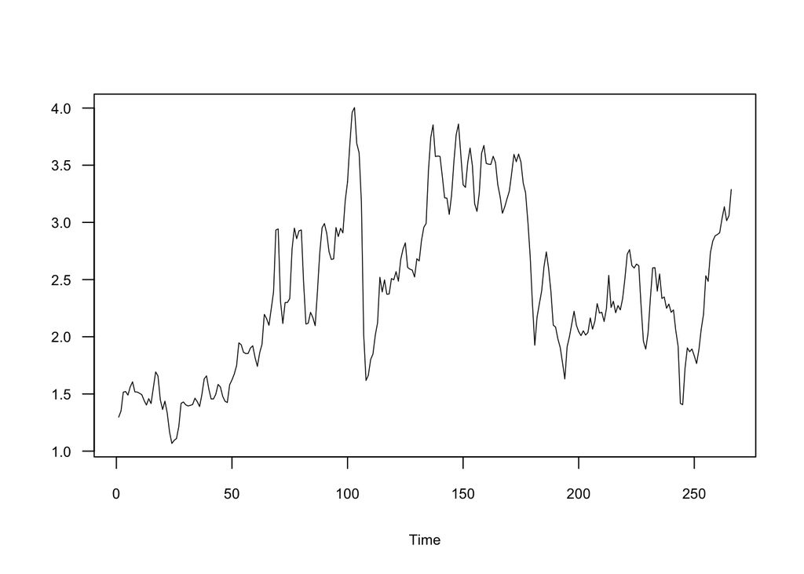

```r
plotts.wge(df$GAS_P)
```

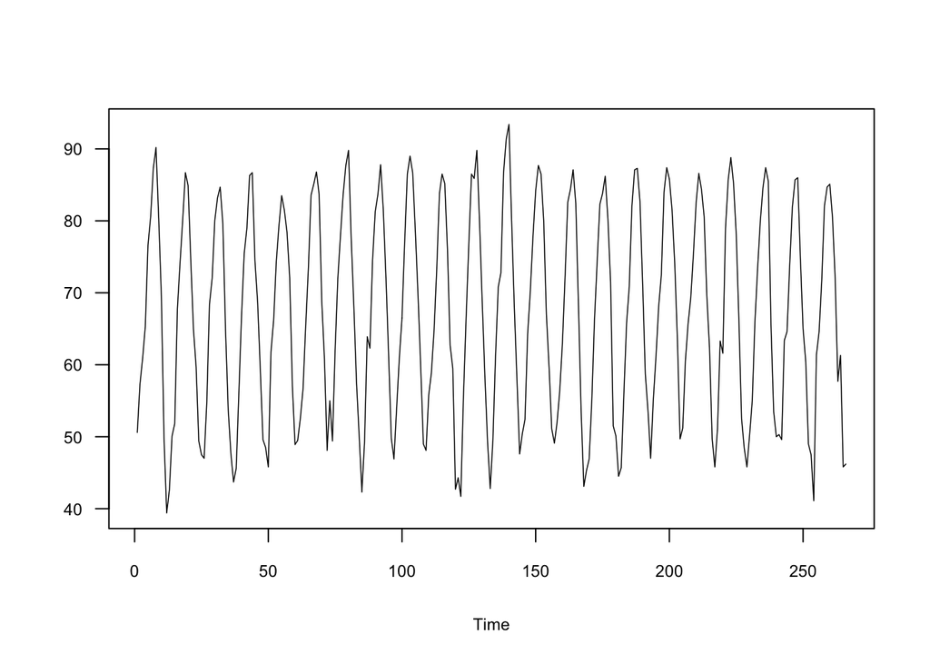

```r
plotts.wge(df$TEMP)
```

#### EDA and Univariate Modeling

- Short term forecast horizon is determined to be 3 month since it might be helpful for short term enerage usage planning
- Long term forecast horizen is determined to be 36 month, since it is helpful to forecast pricing few years out for infrastructure and budget planning

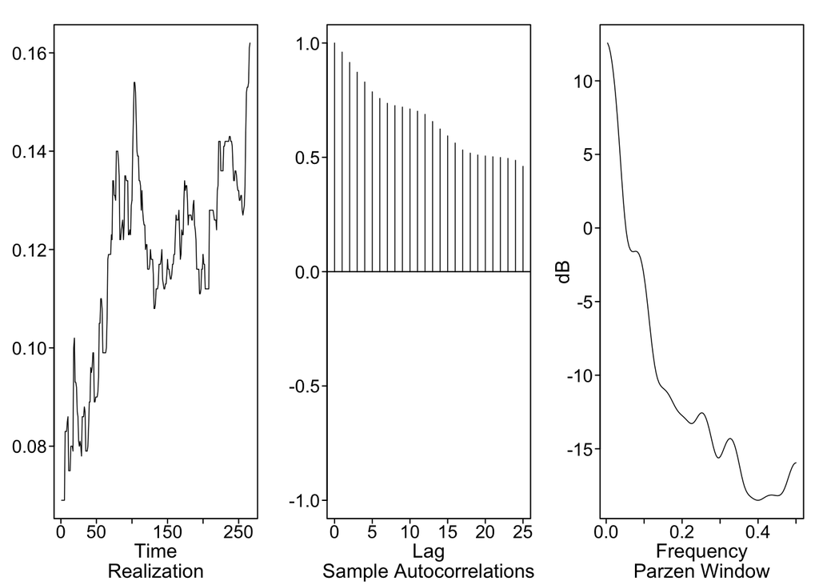

```
## $xbar
## [1] 0.1177444
##
## $autplt
##  [1] 1.0000000 0.9602995 0.9151642 0.8723585 0.8295085 0.7865279 0.7574500
##  [8] 0.7362720 0.7262652 0.7196580 0.7114933 0.7017810 0.6879721 0.6568276
## [15] 0.6238992 0.5937430 0.5625050 0.5322346 0.5184125 0.5104122 0.5059540
## [22] 0.5026686 0.4994694 0.4952331 0.4869328 0.4606747
##
## $freq
##   [1] 0.003759398 0.007518797 0.011278195 0.015037594 0.018796992 0.022556391
##   [7] 0.026315789 0.030075188 0.033834586 0.037593985 0.041353383 0.045112782
##  [13] 0.048872180 0.052631579 0.056390977 0.060150376 0.063909774 0.067669173
##  [19] 0.071428571 0.075187970 0.078947368 0.082706767 0.086466165 0.090225564
##  [25] 0.093984962 0.097744361 0.101503759 0.105263158 0.109022556 0.112781955
```

[output cut: 43 more lines]

```r
# There seem to be a slowly damping behavior which might support difference the data
plotts.sample.wge(df$AVG_EP)
```

```r
# Try overfitting
est = est.ar.wge(df$AVG_EP, p=16, type='burg')
```

```
##
##
## Coefficients of AR polynomial:
## 1.1098 -0.0493 -0.1180 0.0863 -0.1701 0.1127 -0.0761 0.0744 0.0928 -0.2121 0.1797 0.3475 -0.4070 -0.0942 0.1370 -0.0341
##
##                            AR Factor Table
## Factor                 Roots                Abs Recip    System Freq
## 1-0.9605B              1.0411               0.9605       0.0000
## 1-0.0146B+0.9208B^2    0.0079+-1.0421i      0.9596       0.2488
## 1+0.9509B+0.9131B^2   -0.5207+-0.9078i      0.9555       0.3329
## 1-1.6443B+0.9007B^2    0.9128+-0.5264i      0.9490       0.0833
## 1-0.9206B+0.8507B^2    0.5411+-0.9395i      0.9224       0.1668
## 1-0.9208B              1.0861               0.9208       0.0000
## 1+1.4952B+0.7387B^2   -1.0120+-0.5740i      0.8595       0.4179
## 1+0.8128B             -1.2303               0.8128       0.5000
## 1+0.7275B             -1.3745               0.7275       0.5000
## 1-0.6354B+0.1371B^2    2.3176+-1.3870i      0.3702       0.0858
##
##
```

```r
# compare this to seasonality of 12
factor.wge(phi = c(rep(0,11),1))
```

```
##
##
## Coefficients of AR polynomial:
## 0.0000 0.0000 0.0000 0.0000 0.0000 0.0000 0.0000 0.0000 0.0000 0.0000 0.0000 1.0000
##
##                            AR Factor Table
## Factor                 Roots                Abs Recip    System Freq
## 1-1.0000B+1.0000B^2    0.5000+-0.8660i      1.0000       0.1667
## 1-1.0000B              1.0000               1.0000       0.0000
## 1-1.7321B+1.0000B^2    0.8660+-0.5000i      1.0000       0.0833
## 1+1.0000B+1.0000B^2   -0.5000+-0.8660i      1.0000       0.3333
## 1-0.0000B+1.0000B^2    0.0000+-1.0000i      1.0000       0.2500
## 1+1.7321B+1.0000B^2   -0.8660+-0.5000i      1.0000       0.4167
## 1+1.0000B             -1.0000               1.0000       0.5000
##
##
```

```r
# By using overfitting method, 1-B term seems to have the largest absolute reciprocal root which by itself supports differencing the data
# Additionally, there seem to have a 1-B^12 seasonality, even some of the factors such as 1+B at system frequency of -.5 and 1+1.73B+1B^2 at System frequency of 0.4167 are not as close to the unit circle. Although it might worth exploring s = 12 also

d1 = artrans.wge(df$AVG_EP, phi.tr = 1)
```

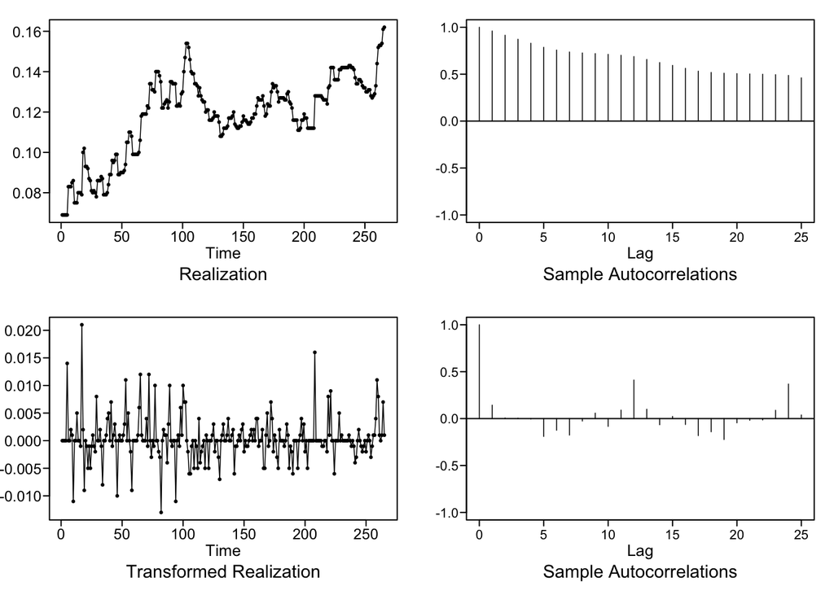

```r
# with the differenced data there seem to have some sort of seasonal behavior at 12 left
d1.12 = artrans.wge(d1, phi.tr = c(rep(0,11),0.4))
```

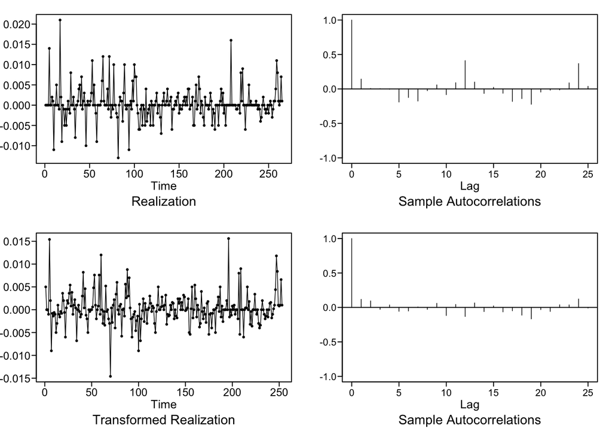

```r
dev.off()
```

```r
acf(d1.12) # AIC looks about white noise
ljung.wge(d1.12, K=24) # K=24 reject white noise hypothesis
```

```
## Obs 0.1177406 0.09510556 -0.02821038 0.03577436 -0.05663082 -0.05190919 0.007935022 -0.02846601 0.06039309 -0.1174017 0.04320217 -0.1317076 0.06581953 -0.06049459 0.02239541 -0.06491078 -0.04911588 -0.1121 -0.1665538 -0.03136583 -0.05822815 0.03840348 0.03680909 0.1222457
```

```
## $test
## [1] "Ljung-Box test"
##
## $K
## [1] 24
##
## $chi.square
## [1] 39.35395
##
## $df
## [1] 24
##
## $pval
## [1] 0.02506178
```

```r
ljung.wge(d1.12, K=48) # K = 48 reject white noise
```

```
## Obs 0.1177406 0.09510556 -0.02821038 0.03577436 -0.05663082 -0.05190919 0.007935022 -0.02846601 0.06039309 -0.1174017 0.04320217 -0.1317076 0.06581953 -0.06049459 0.02239541 -0.06491078 -0.04911588 -0.1121 -0.1665538 -0.03136583 -0.05822815 0.03840348 0.03680909 0.1222457 -0.009325486 -0.03049484…
```

```
## $test
## [1] "Ljung-Box test"
##
## $K
## [1] 48
##
## $chi.square
## [1] 84.83926
##
## $df
## [1] 48
##
## $pval
## [1] 0.0008252289
```

```r
# Thus models require further modeling

# est1.12 = aic5.wge(d1.12, p=0:15, q=0:5) # AIC picked p = 7, q=4
# est.1.12.bic = aic5.wge(d1.12, p=0:15, q=0:5, type = 'bic') # bic picked p=0, q=0
# est.1.12.aicc = aic5.wge(d1.12, p=0:15, q=0:5, type = 'aicc') # aicc picked p=1, q=0
# seems AIC leaning towards a fancy model, while bic leaning towards white noise.
# I will attempt something in the middle by using AR(1) instead
params.est = est.arma.wge(d1.12, p=1)
```

```
##
##
## Coefficients of AR polynomial:
## 0.1182
##
##                            AR Factor Table
## Factor                 Roots                Abs Recip    System Freq
## 1-0.1182B              8.4627               0.1182       0.0000
##
##
```

```r
acf(params.est$res) # residuals looks about white noise
ljung.wge(params.est$res, K=24) # K=24 reject white noise hypothesis
```

```
## Obs -0.01014382 0.08726767 -0.04465155 0.04663999 -0.05631173 -0.04714291 0.01811757 -0.03731123 0.0796301 -0.1331266 0.07436933 -0.1485251 0.09073813 -0.07272263 0.03809915 -0.06359699 -0.02927703 -0.08955453 -0.154185 -0.005329216 -0.06060576 0.04209565 0.01856966 0.1223151
```

```
## $test
## [1] "Ljung-Box test"
##
## $K
## [1] 24
##
## $chi.square
## [1] 38.64312
##
## $df
## [1] 24
##
## $pval
## [1] 0.02975776
```

```r
ljung.wge(params.est$res, K=48) # K = 48reject null hypothesis of white noise
```

```
## Obs -0.01014382 0.08726767 -0.04465155 0.04663999 -0.05631173 -0.04714291 0.01811757 -0.03731123 0.0796301 -0.1331266 0.07436933 -0.1485251 0.09073813 -0.07272263 0.03809915 -0.06359699 -0.02927703 -0.08955453 -0.154185 -0.005329216 -0.06060576 0.04209565 0.01856966 0.1223151 -0.02076998 -0.02871…
```

```
## $test
## [1] "Ljung-Box test"
##
## $K
## [1] 48
##
## $chi.square
## [1] 79.38565
##
## $df
## [1] 48
##
## $pval
## [1] 0.002934686
```

```r
# Try fancier model identified by AIC
params.est = est.arma.wge(d1.12, p=7,q=4)
```

```
##
##
## Coefficients of AR polynomial:
## -0.8600 -0.1354 -0.9232 -0.6079 0.1714 -0.0515 -0.0085
##
##                            AR Factor Table
## Factor                 Roots                Abs Recip    System Freq
## 1+1.8898B+0.9402B^2   -1.0050+-0.2314i      0.9696       0.4640
## 1-0.7621B+0.8873B^2    0.4294+-0.9709i      0.9420       0.1837
## 1-0.3782B+0.0918B^2    2.0591+-2.5786i      0.3030       0.1428
## 1+0.1104B             -9.0565               0.1104       0.5000
##
##
##
##
## Coefficients of MA polynomial:
## -1.0151 -0.3327 -1.0074 -0.7941
##
##                               MA FACTOR TABLE
## Factor                 Roots                Abs Recip    System Freq
## 1-0.7997B+0.9310B^2    0.4295+-0.9432i      0.9649       0.1820
## 1+1.8148B+0.8530B^2   -1.0638+-0.2018i      0.9236       0.4702
##
##
```

```r
acf(params.est$res) # residuals looks about white noise
ljung.wge(params.est$res, K=24) # K=24 fail to reject white noise hypothesis
```

```
## Obs 0.0008823033 0.007168264 0.01503579 -0.002268612 -0.04788816 0.004909812 -0.009460663 0.01731718 -0.01596821 -0.05734878 0.0002766386 -0.04294852 0.006864266 -0.00473022 -0.04453687 -0.005459694 -0.0516052 -0.04690075 -0.1718459 -0.00778543 -0.05177915 0.0191305 0.05259443 0.08994917
```

```
## $test
## [1] "Ljung-Box test"
##
## $K
## [1] 24
##
## $chi.square
## [1] 16.1709
##
## $df
## [1] 24
##
## $pval
## [1] 0.8818087
```

```r
ljung.wge(params.est$res, K=48) # K = 48 fail to reject null hypothesis of white noise
```

```
## Obs 0.0008823033 0.007168264 0.01503579 -0.002268612 -0.04788816 0.004909812 -0.009460663 0.01731718 -0.01596821 -0.05734878 0.0002766386 -0.04294852 0.006864266 -0.00473022 -0.04453687 -0.005459694 -0.0516052 -0.04690075 -0.1718459 -0.00778543 -0.05177915 0.0191305 0.05259443 0.08994917 0.017605…
```

```
## $test
## [1] "Ljung-Box test"
##
## $K
## [1] 48
##
## $chi.square
## [1] 58.63666
##
## $df
## [1] 48
##
## $pval
## [1] 0.1397722
```

```r
# All models are wrong some are useful - we will proceed with fancier model for now
model1.param = mult.wge(fac1 = params.est$phi, fac2 = c(rep(0,11),0.4))
pred.short = fore.arima.wge(df$AVG_EP, phi = model1.param$model.coef, theta = params.est$theta,
                            d = 1, n.ahead = 3, limits = T, lastn = T)
ASE.short = mean((df$AVG_EP[264:266]-pred.short$f)^2)
ASE.short # 3.184093e-05 -> 0.0000318  #New 5.988891e-05 -> 0.0000599
```

```
## [1] 5.988891e-05
```

```r
pred.long = fore.arima.wge(df$AVG_EP, phi = model1.param$model.coef, theta = params.est$theta,
                            d = 1, n.ahead = 36, limits = T, lastn = T)
ASE.long = mean((df$AVG_EP[(266-36+1):266]-pred.long$f)^2)
ASE.long # 0.0001725023
```

```
## [1] 0.0001725023
```

```r
# rolling.res.short = roll.win.rmse.wge(df$AVG_EP,phi = model1.param$model.coef, theta = params.est$theta, d = 1, horizon = 3 )
# rolling.res.short # RMSE = 0.004, ASE = 1.6e-0.5 -> 0.000016, nums of windows = 239

# rolling.res.long = roll.win.rmse.wge(df$AVG_EP,phi = model1.param$model.coef, theta = params.est$theta, d = 1, horizon = 36)
# rolling.res.long # RMSE = 0.014, ASE= 0.000196, num of windows = 206
```

#### Univariate signal plus noise model

- This section created a signal plus noise model. However, was not utilized as the final model during presentation
- There is no rolling window ASE to be used for comparison with other models only test ASE

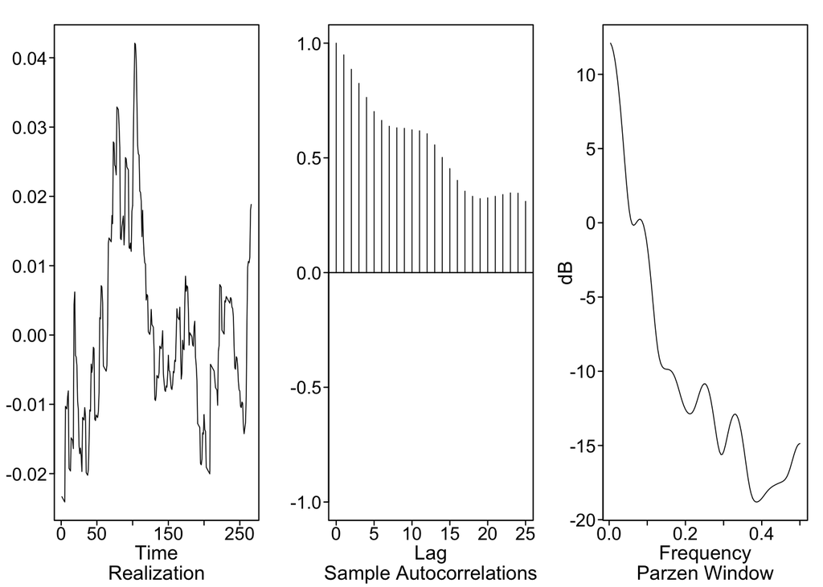

```
## $xbar
## [1] -1.589301e-16
##
## $autplt
##  [1] 1.0000000 0.9489817 0.8860380 0.8248767 0.7634339 0.7020367 0.6633172
##  [8] 0.6378392 0.6311052 0.6288295 0.6223238 0.6178089 0.6051494 0.5567153
## [15] 0.5020588 0.4530965 0.4019963 0.3547485 0.3324767 0.3224324 0.3258818
## [22] 0.3325654 0.3401354 0.3471977 0.3461759 0.3106075
##
## $freq
##   [1] 0.003759398 0.007518797 0.011278195 0.015037594 0.018796992 0.022556391
##   [7] 0.026315789 0.030075188 0.033834586 0.037593985 0.041353383 0.045112782
##  [13] 0.048872180 0.052631579 0.056390977 0.060150376 0.063909774 0.067669173
##  [19] 0.071428571 0.075187970 0.078947368 0.082706767 0.086466165 0.090225564
##  [25] 0.093984962 0.097744361 0.101503759 0.105263158 0.109022556 0.112781955
```

[output cut: 43 more lines]

```r
x = df$AVG_EP
n = length(x)
t = 1:n
d = lm(x~t)
# x.z are the residuals from the regression line
x.z = x-d$coefficients[1] - d$coefficients[2]*t
plotts.sample.wge(x.z)
```

```r
ar.z = aic.wge(x.z, p=0:15)
x.trans = artrans.wge(x, phi.tr = ar.z$phi)
```

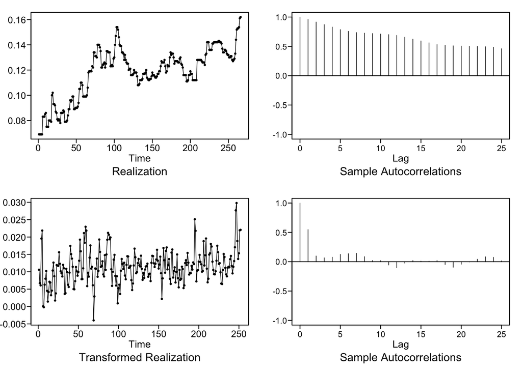

```r
t.trans = artrans.wge(t, phi.tr = ar.z$phi)
```

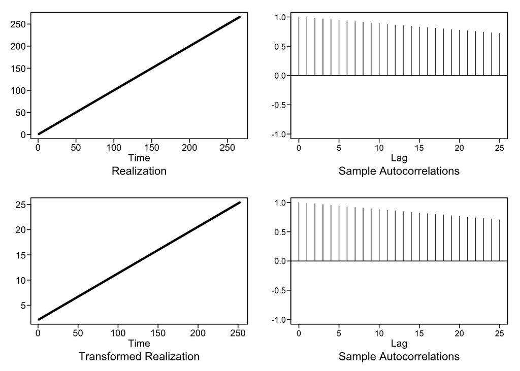